# Praca zaliczeniowa na przedmiot Modelowanie ryzyka kredytowego oraz budowy kart scoringowych w R

Katarzyna Chyrowicz, Szymon Lesiak

10 luty 2018

# Analiza danych

Baza danych, która została wykorzystana do analizy, dotyczy wyników kampanii marketingowej portugalskiego banku. Polegała ona na wykonywaniu telefonów do potencjalnych klientów i zachęcaniu do zakupu produktu, którym był depozyt bankowy. W 5289 przypadkach zakończyła się ona sukcesem, w 39922 przypadkach porażką. Niniejsza analiza ma na celu oszacowanie czynników wpływających na prawdopodobieństwo sukcesu.

W bazie danych dostępnych jest 16 zmiennych objaśniających, których podstawowe statystyki opisowe widać poniżej.

|  | age | job | marital | education | default | balance | housing | loan | contact | year | week_day | duration | campaign | pdays | previous | poutcome | DEF |
| --- | --- | --- | --- | --- | --- | --- | --- | --- | --- | --- | --- | --- | --- | --- | --- | --- | --- |
|  | Min. :18.00 | blue-collar:9732 | divorced: 5207 | primary : 6851 | no :44396 | Min. : -8019 | no :20081 | no :37967 | cellular :29285 | Min. :2008 | Min. :1.000 | Min. : 0.0 | Min. : 1.000 | Min. : -1.0 | Min. : 0.0000 | failure: 4901 | Min. :0.000 |
|  | 1st Qu.:33.00 | management :9458 | married :27214 | secondary:23202 | yes: 815 | 1st Qu.: 72 | yes:25130 | yes: 7244 | telephone: 2906 | 1st Qu.:2008 | 1st Qu.:2.000 | 1st Qu.: 103.0 | 1st Qu.: 1.000 | 1st Qu.: -1.0 | 1st Qu.: 0.0000 | other : 1840 | 1st Qu.:0.000 |
|  | Median :39.00 | technician :7597 | single :12790 | tertiary :13301 | NA | Median : 448 | NA | NA | unknown :13020 | Median :2008 | Median :3.000 | Median : 180.0 | Median : 2.000 | Median : -1.0 | Median : 0.0000 | success: 1511 | Median :0.000 |
|  | Mean :40.94 | admin. :5171 | NA | unknown : 1857 | NA | Mean : 1362 | NA | NA | NA | Mean :2008 | Mean :3.001 | Mean : 258.2 | Mean : 2.764 | Mean : 40.2 | Mean : 0.5803 | unknown:36959 | Mean :0.117 |
|  | 3rd Qu.:48.00 | services :4154 | NA | NA | NA | 3rd Qu.: 1428 | NA | NA | NA | 3rd Qu.:2009 | 3rd Qu.:4.000 | 3rd Qu.: 319.0 | 3rd Qu.: 3.000 | 3rd Qu.: -1.0 | 3rd Qu.: 0.0000 | NA | 3rd Qu.:0.000 |
|  | Max. :95.00 | retired :2264 | NA | NA | NA | Max. :102127 | NA | NA | NA | Max. :2010 | Max. :7.000 | Max. :4918.0 | Max. :63.000 | Max. :871.0 | Max. :275.0000 | NA | Max. :1.000 |
|  | NA | (Other) :6835 | NA | NA | NA | NA | NA | NA | NA | NA | NA | NA | NA | NA | NA | NA | NA |

*Age* to zmienna określająca wiek klienta, *job* typ wykonywanej przez niego pracy, przyjmujący 12 poziomów, *marital* to stan cywilny klienta (3 poziomy), *education* poziom wykształcenia klienta (podstawowe, średnie, wyższe, nieznane). Zmienna *default* przyjmuje poziom *yes* dla klientów, którzy posiadają kredyt w defaulcie, *no* w przeciwnym przypadku, *balance* to saldo na koncie, *housing* określa, czy klient ma kredyt mieszkaniowy, *loan*, czy klient posiada pożyczkę osobistą. *Contact* oznacza kontakt komórkowy, telefoniczny lub nieznany z klientem, *year* to rok, w którym kampania została przeprowadzona (2008-2010), *week_day* określa dzień tygodnia, w którym została ona zaadresowana do klienta. *Duration* to czas ostatniej rozmowy z klientem, w celu przekonania do zakupu produktu. Jest on znany dopiero po kontakcie, kiedy znany jest już wynik kampanii, dlatego nie będzie można wykorzystać tej zmiennej bezpośrednio do modelowania. *Campaign* określa liczbę kontaktów z klientem w prowadzonej kampanii, *pdays* to liczba dni, które upłynęły od kontaktu z poprzedniej kampanii, *previous* to liczba kontaktów z klientem przed obecną kampanią, *poutcome* to wynik poprzedniej kampanii.

| age | job | marital | education | default | balance | housing | loan | contact | year | week_day | duration | campaign | pdays | previous | poutcome | DEF | previous2 | if_previous | campaign2 |
| --- | --- | --- | --- | --- | --- | --- | --- | --- | --- | --- | --- | --- | --- | --- | --- | --- | --- | --- | --- |
| 58 | management | married | tertiary | no | 2143 | yes | no | unknown | 2008 | 1 | 261 | 1 | -1 | 0 | unknown | 0 | 0 | 0 | 1 |
| 44 | technician | single | secondary | no | 29 | yes | no | unknown | 2008 | 1 | 151 | 1 | -1 | 0 | unknown | 0 | 0 | 0 | 1 |
| 33 | entrepreneur | married | secondary | no | 2 | yes | yes | unknown | 2008 | 1 | 76 | 1 | -1 | 0 | unknown | 0 | 0 | 0 | 1 |
| 47 | blue-collar | married | unknown | no | 1506 | yes | no | unknown | 2008 | 1 | 92 | 1 | -1 | 0 | unknown | 0 | 0 | 0 | 1 |
| 33 | unknown | single | unknown | no | 1 | no | no | unknown | 2008 | 1 | 198 | 1 | -1 | 0 | unknown | 0 | 0 | 0 | 1 |
| 35 | management | married | tertiary | no | 231 | yes | no | unknown | 2008 | 1 | 139 | 1 | -1 | 0 | unknown | 0 | 0 | 0 | 1 |
| 28 | management | single | tertiary | no | 447 | yes | yes | unknown | 2008 | 1 | 217 | 1 | -1 | 0 | unknown | 0 | 0 | 0 | 1 |
| 42 | entrepreneur | divorced | tertiary | yes | 2 | yes | no | unknown | 2008 | 1 | 380 | 1 | -1 | 0 | unknown | 0 | 0 | 0 | 1 |
| 58 | retired | married | primary | no | 121 | yes | no | unknown | 2008 | 1 | 50 | 1 | -1 | 0 | unknown | 0 | 0 | 0 | 1 |
| 43 | technician | single | secondary | no | 593 | yes | no | unknown | 2008 | 1 | 55 | 1 | -1 | 0 | unknown | 0 | 0 | 0 | 1 |

Kolejnym ważnym krokiem we wstępnej analizie danych jest sprawdzenie liczebności braków danych. Jak widać w tabeli ponieżej, problem ten nie występuje dla wybranej bazy.

|  | x |
| --- | --- |
| age | 0 |
| job | 0 |
| marital | 0 |
| education | 0 |
| default | 0 |
| balance | 0 |
| housing | 0 |
| loan | 0 |
| contact | 0 |
| year | 0 |
| week_day | 0 |
| duration | 0 |
| campaign | 0 |
| pdays | 0 |
| previous | 0 |
| poutcome | 0 |
| DEF | 0 |
| previous2 | 0 |
| if_previous | 0 |
| campaign2 | 0 |

Następnie została przeprowadzona analiza zależności między zmienną określającą poziom wykształcenia klienta oraz sukcesem kampanii. Na podstawie testu Ch-kwadrat należy odrzucić hipotezę zerową, że sukces nie zależy od wykształcenia.

```
##
##  Pearson's Chi-squared test
##
## data:  tabelka
## X-squared = 238.8, df = 3, p-value < 2.2e-16
```

Poniżej wykresy udziału sukcesów w zależności od poziomu wykształcenia. Najczęściej produkt był kupowany przez klientów z wyższym wykształceniem.

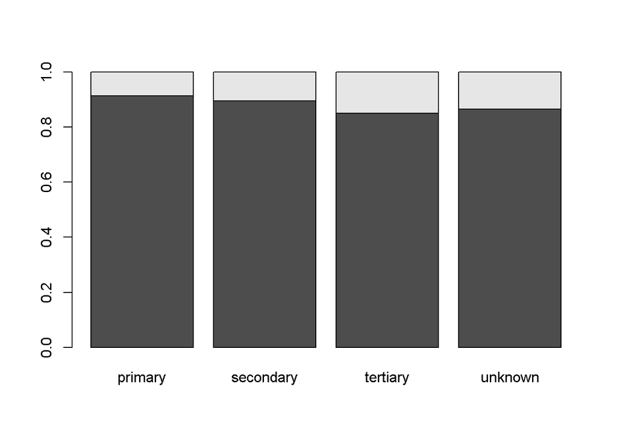

# Przygotowywanie zmiennych WoE

## Fine classing

Kolejnym krokiem analizy będzie przygotowanie zmiennych do fine-classingu. W tym celu zostaną one podzielone na zmienne ciągłe oraz dyskretne.

Wszystkie zmienne ciągłe zostały poddane dyskretyzacji na podstawie wyznaczonych percentyli.

Na poniższych wykresach widać rozkłady zmiennych dla sukcesu i porażki, rozkłady częstości, udział klietnów, którzy zdecydowali się na zakup w każdej grupie oraz wskaźnik WOE. Na jego podstawie można zauważyć, że prawdopodobnie można połączyć niektóre poziomy dla zmiennej *age*, jednak na razie zmienna ta zostanie w pierwotnej postaci.

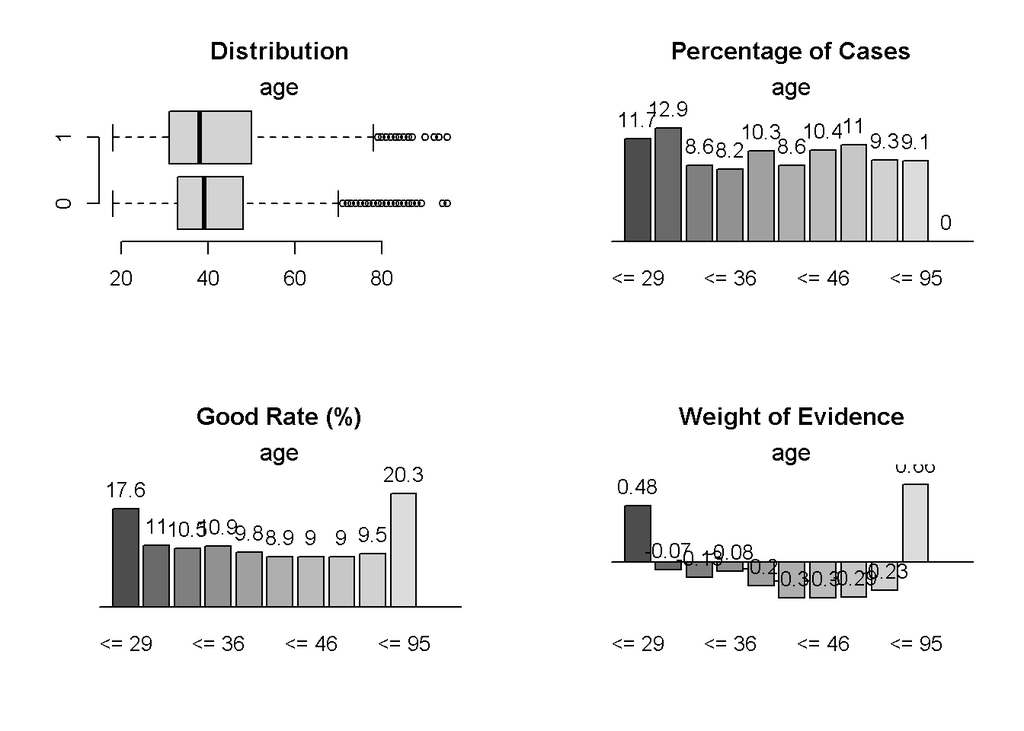

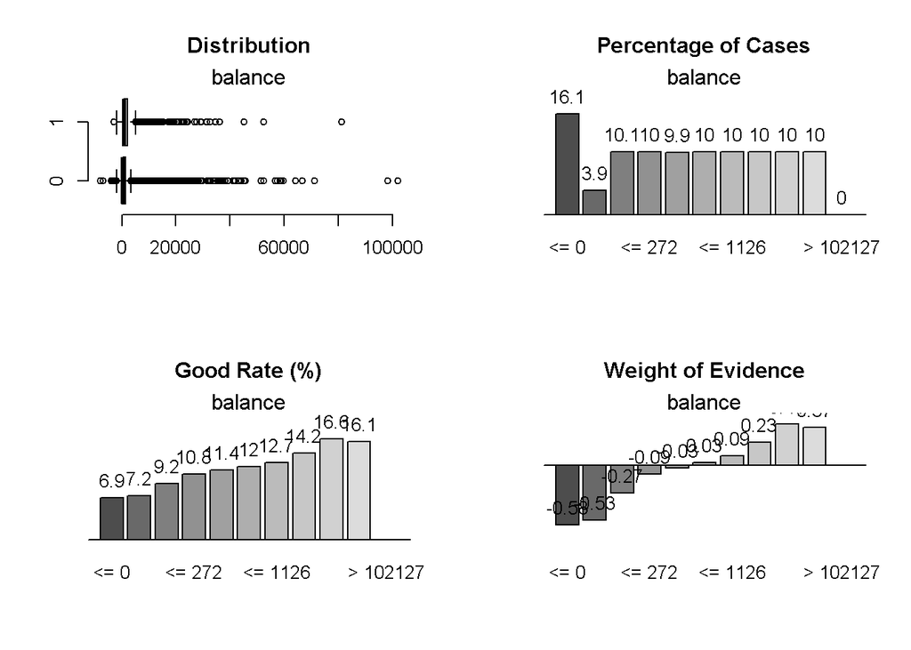

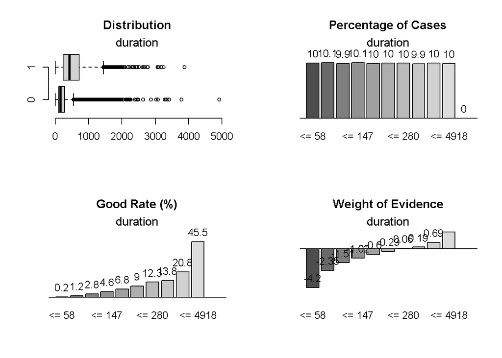

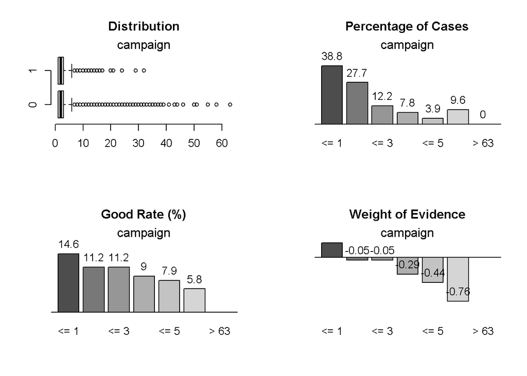

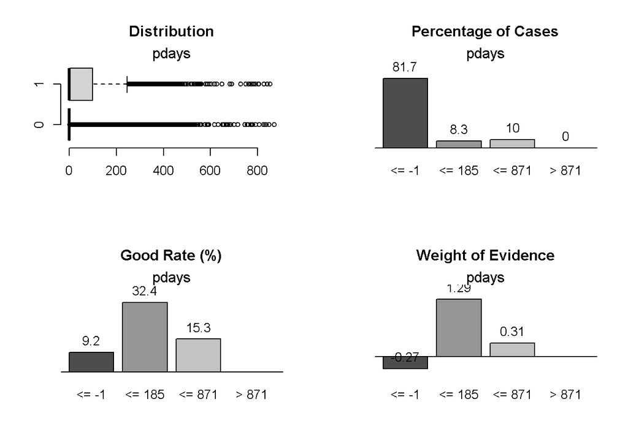

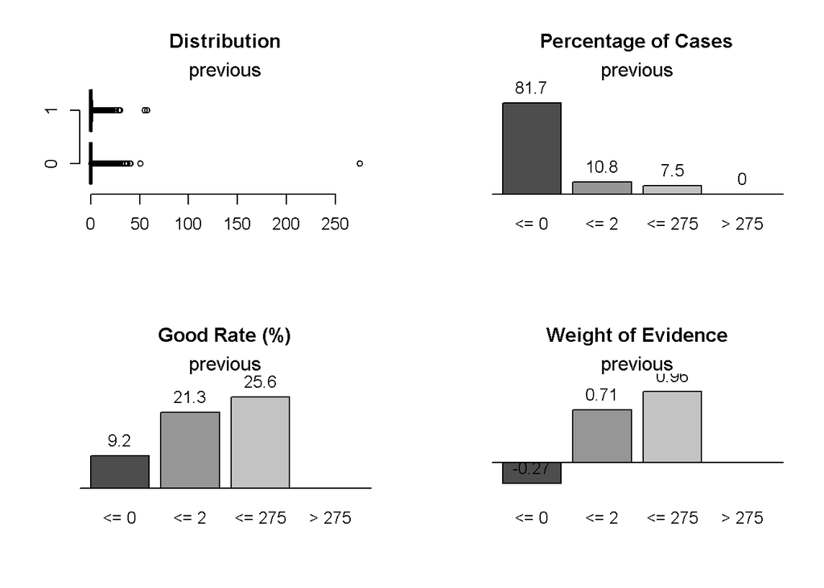

Podobna analiza została wykonana dla zmiennych dyskretynych. Na podstawie wskaźnika WOE zostały połączone poziomy zmiennej *job*. Z *self-employed* i *unknown* powstał poziom *self-employed & unknown*, natomiast z *housmaid* i *services* *housmaid & services*.

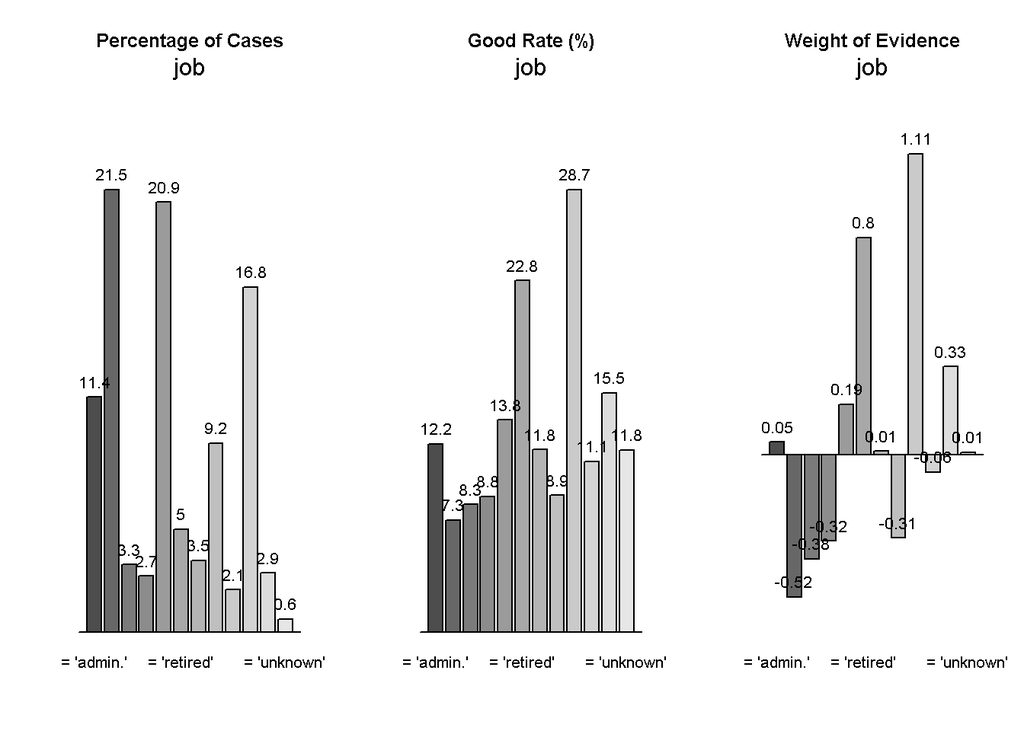

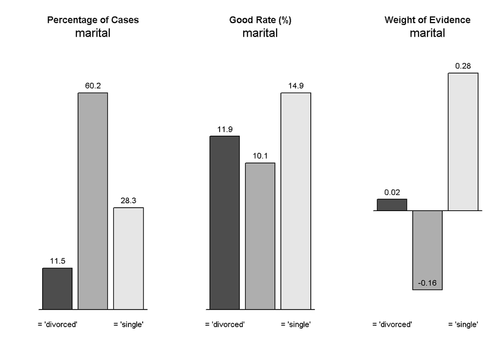

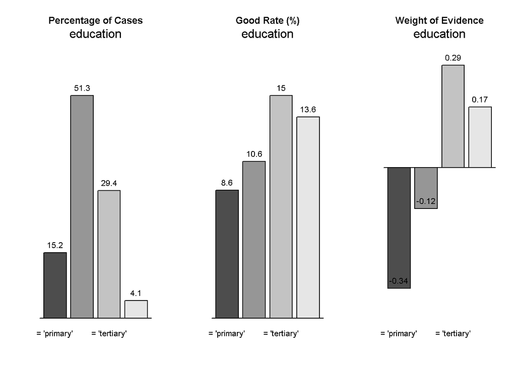

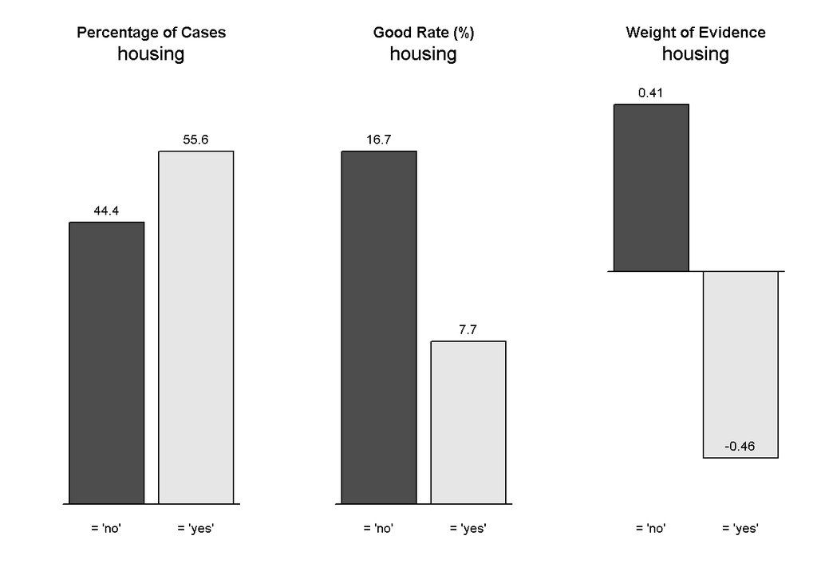

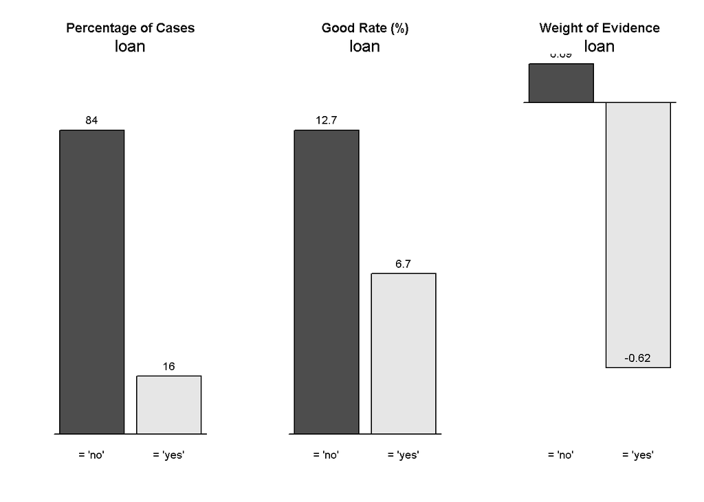

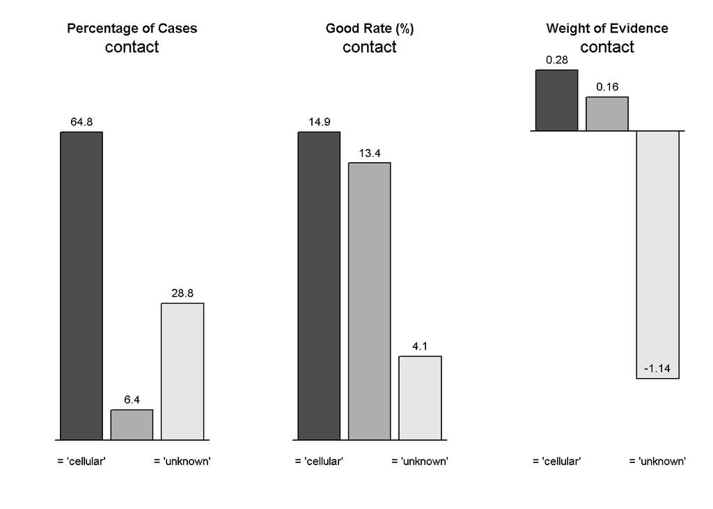

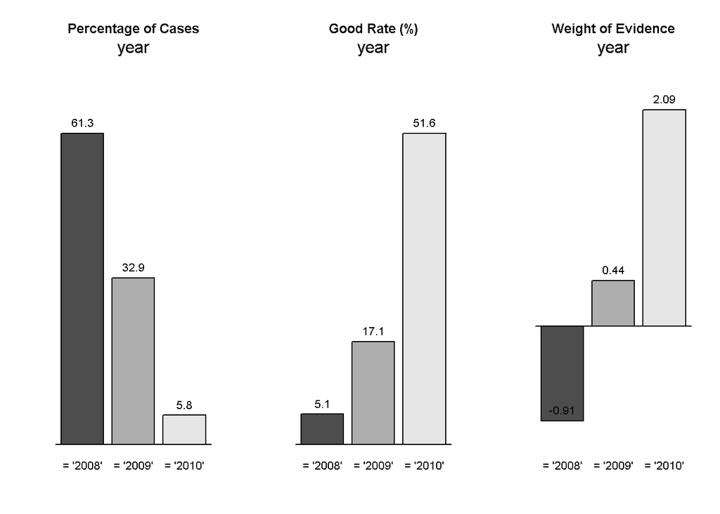

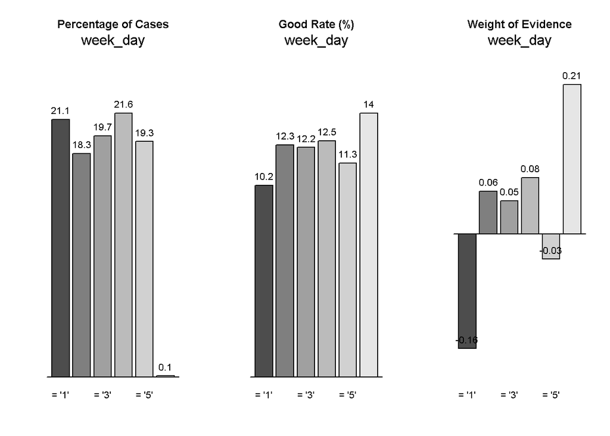

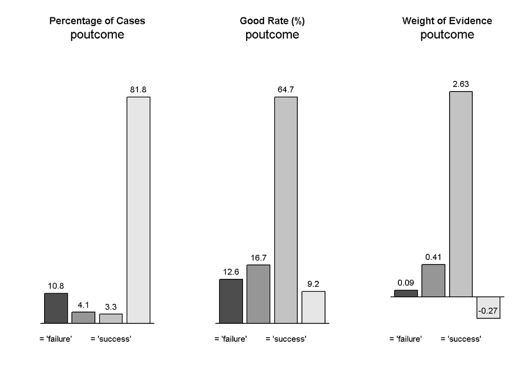

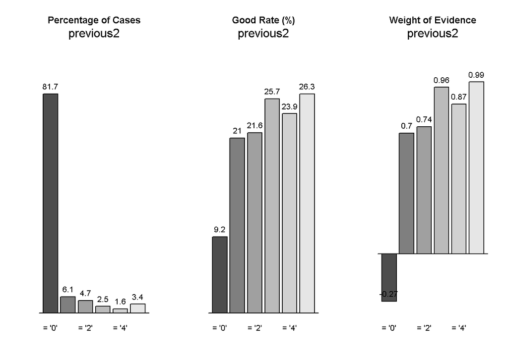

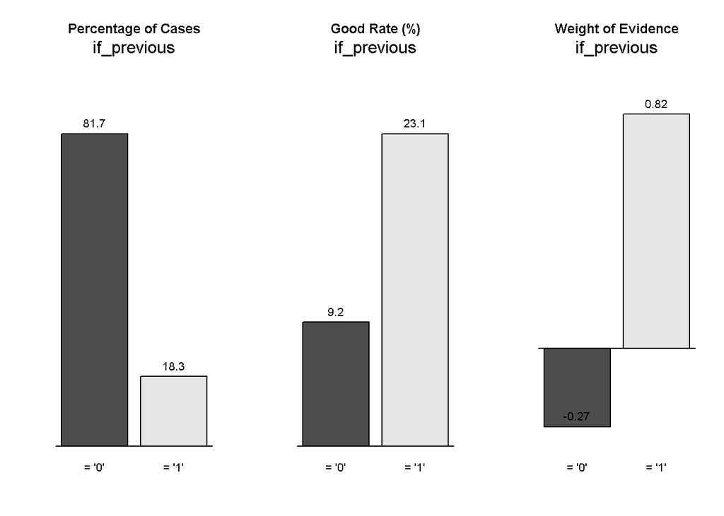

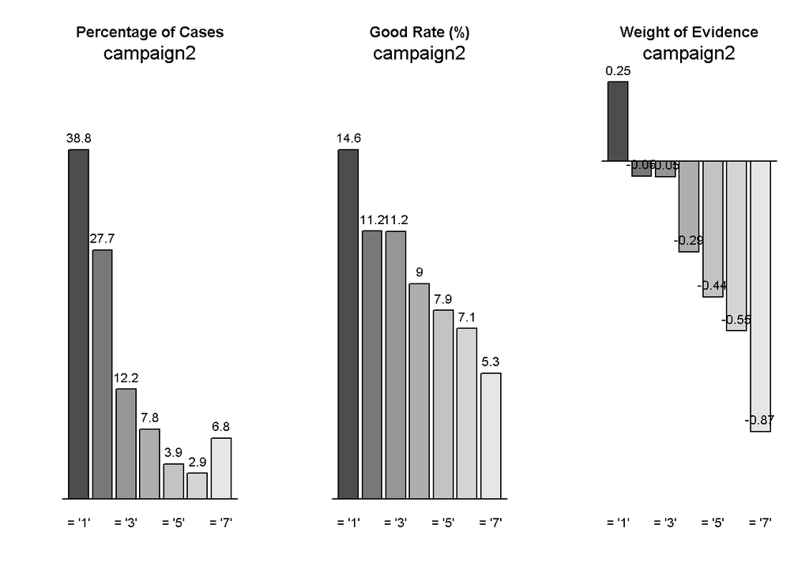

## Coarse claassing

Kolejnym krokiem analizy był podział próby na uczącą (treningową) oraz walidacyjną (testową). Próba treningową stanowi 70% obserwacji, testowa 30%, zostały one dobrane losowo.

Następnie dla każdej z prób został przeprowadzony coarse-classing - dyskretyzacja zmiennych na podstawie drzewa decyzyjnego. Na kolejnych wykresach widać stabilność dla próby treningowej i testowej, rozkład częstości i udział dobrych klientów.

```
## Information Value 0.15
```

```
##      [,1]
## [1,]  0.7
## [2,]  1.9
## [3,]  3.1
## [4,]  4.3
```

```
## [1] 0.7 1.9
```

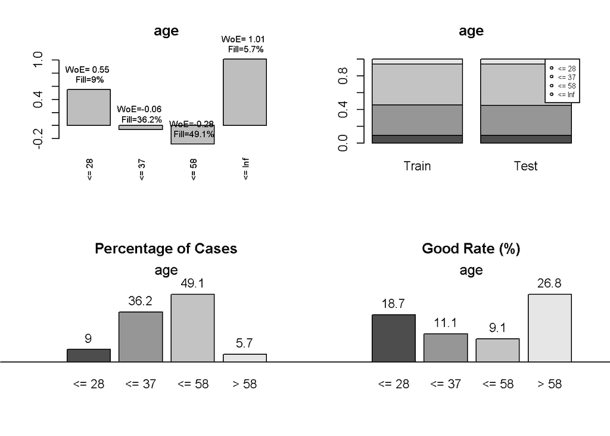

```
## Information Value 0.08
```

```
##      [,1]
## [1,]  0.7
## [2,]  1.9
## [3,]  3.1
## [4,]  4.3
```

```
## [1] 0.7 1.9
```

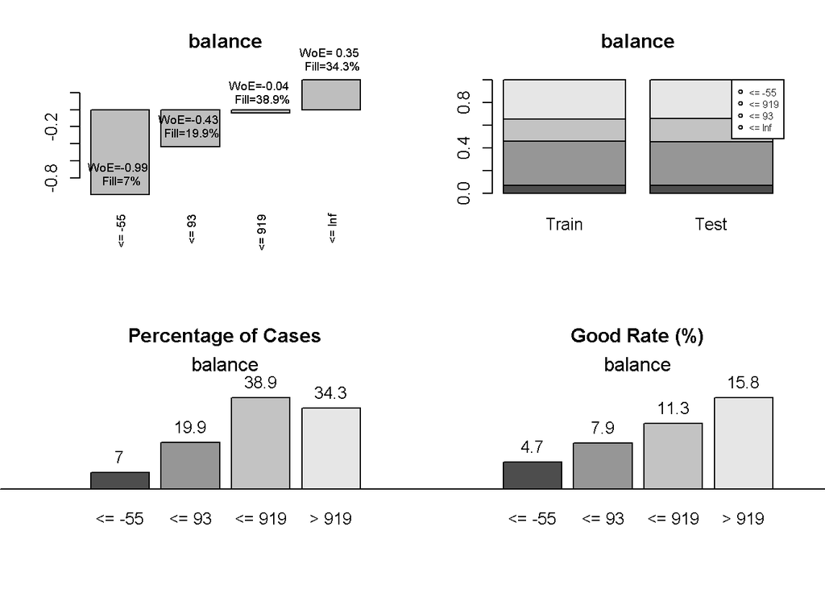

```
## Information Value 1.53
```

```
##       [,1]
##  [1,]  0.7
##  [2,]  1.9
##  [3,]  3.1
##  [4,]  4.3
##  [5,]  5.5
##  [6,]  6.7
##  [7,]  7.9
##  [8,]  9.1
##  [9,] 10.3
```

```
## [1] 0.7 1.9
```

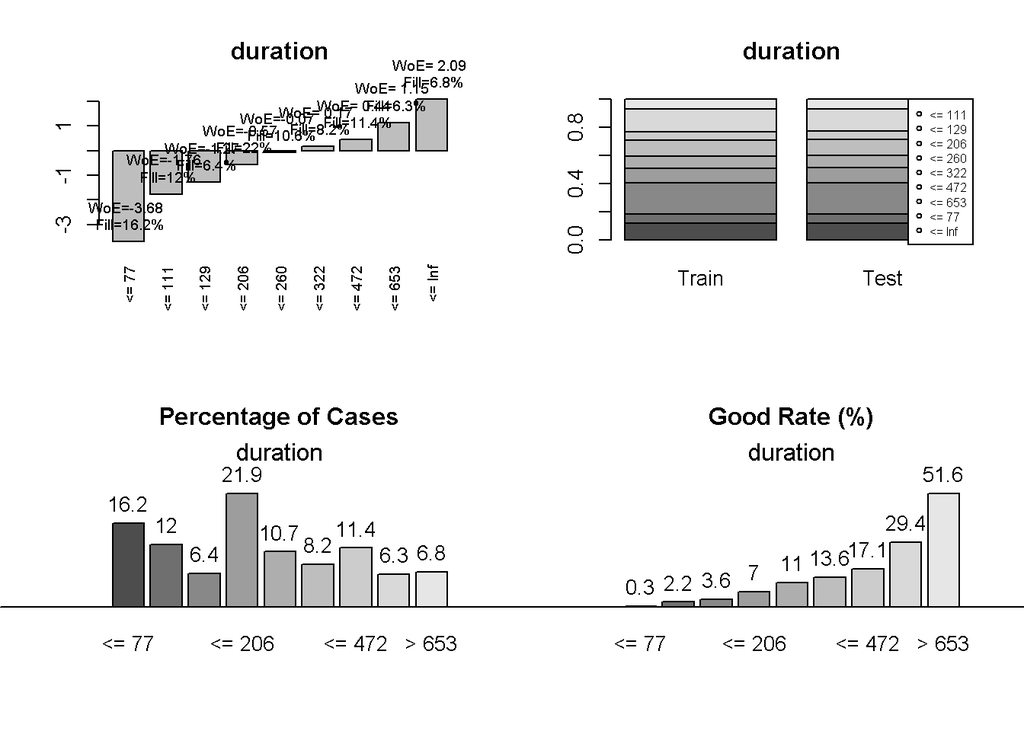

```
## Information Value 0.07
```

```
##      [,1]
## [1,]  0.7
## [2,]  1.9
## [3,]  3.1
## [4,]  4.3
```

```
## [1] 0.7 1.9
```

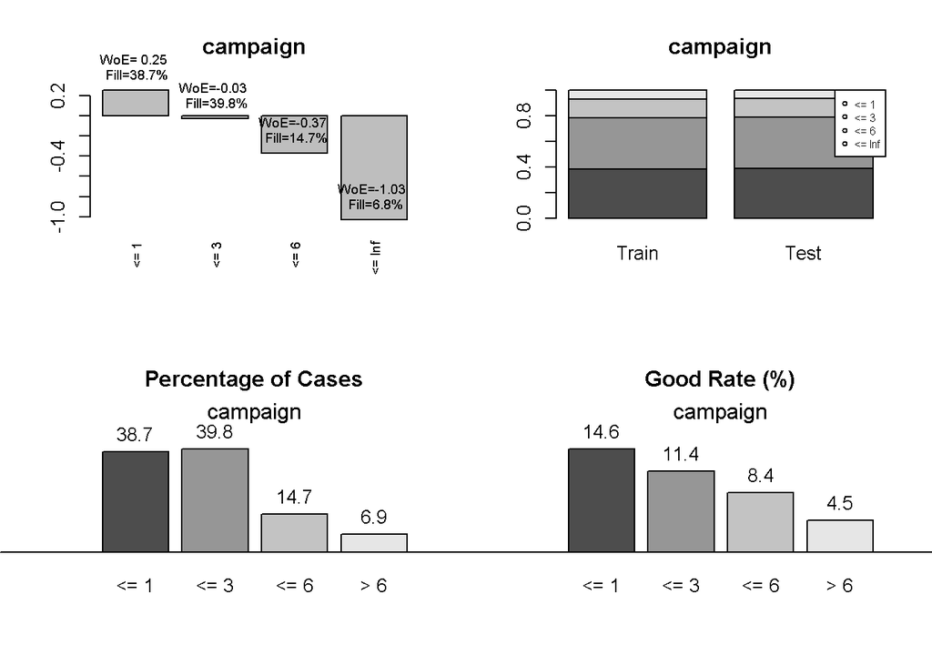

```
## Information Value 0.29
```

```
##      [,1]
## [1,]  0.7
## [2,]  1.9
## [3,]  3.1
```

```
## [1] 0.7 1.9
```

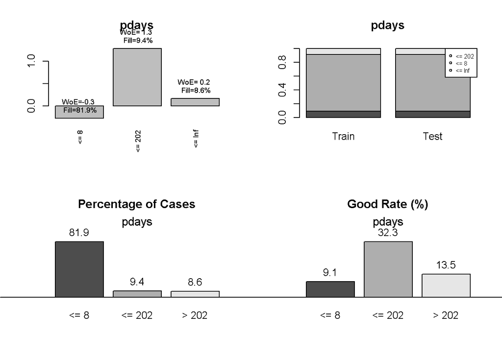

```
## Information Value 0.21
```

```
##      [,1]
## [1,]  0.7
## [2,]  1.9
```

```
## [1] 0.7 1.9
```

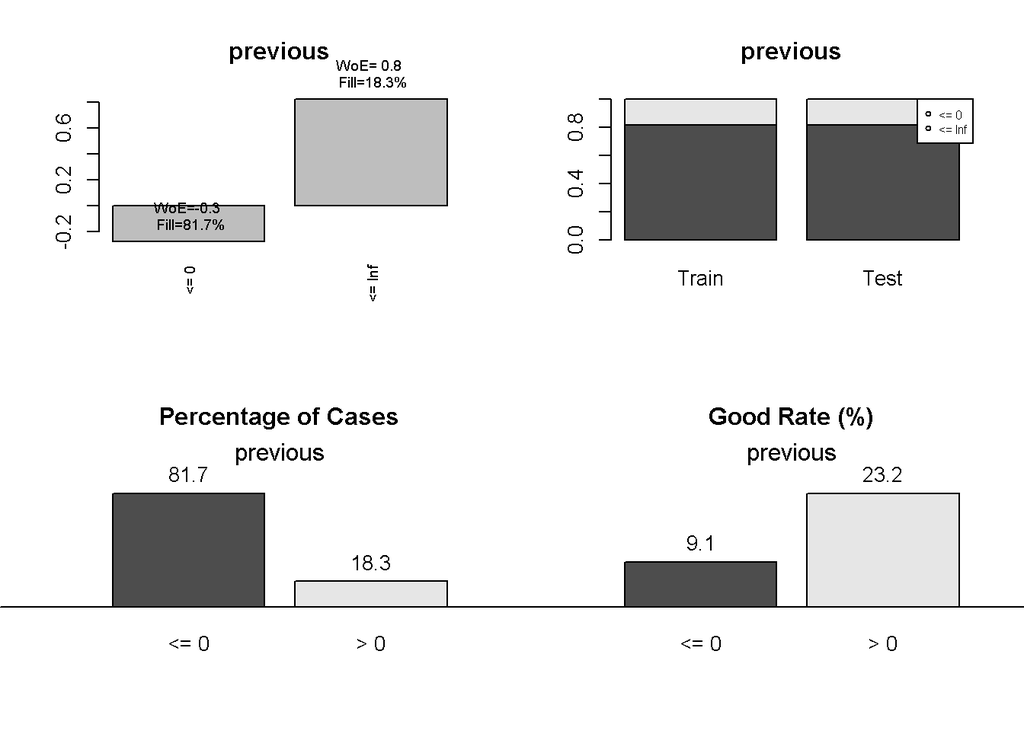

```
## Information Value 0.16
```

```
##       [,1]
##  [1,]  0.7
##  [2,]  1.9
##  [3,]  3.1
##  [4,]  4.3
##  [5,]  5.5
##  [6,]  6.7
##  [7,]  7.9
##  [8,]  9.1
##  [9,] 10.3
## [10,] 11.5
```

```
## [1] 0.7 1.9
```

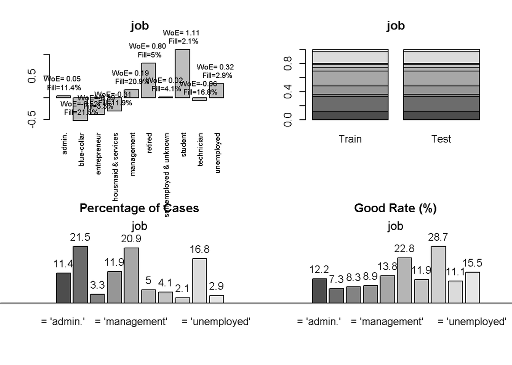

```
## Information Value 0.03
```

```
##      [,1]
## [1,]  0.7
## [2,]  1.9
## [3,]  3.1
```

```
## [1] 0.7 1.9
```

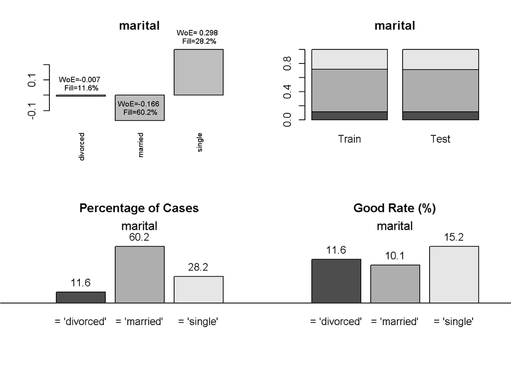

```
## Information Value 0.05
```

```
##      [,1]
## [1,]  0.7
## [2,]  1.9
## [3,]  3.1
## [4,]  4.3
```

```
## [1] 0.7 1.9
```

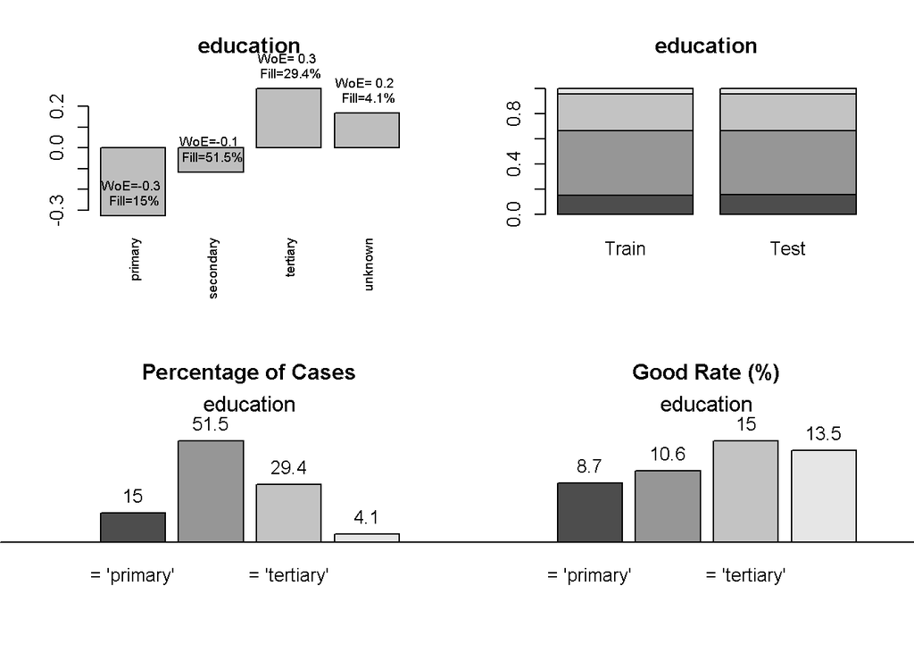

```
## Information Value 0.18
```

```
##      [,1]
## [1,]  0.7
## [2,]  1.9
```

```
## [1] 0.7 1.9
```

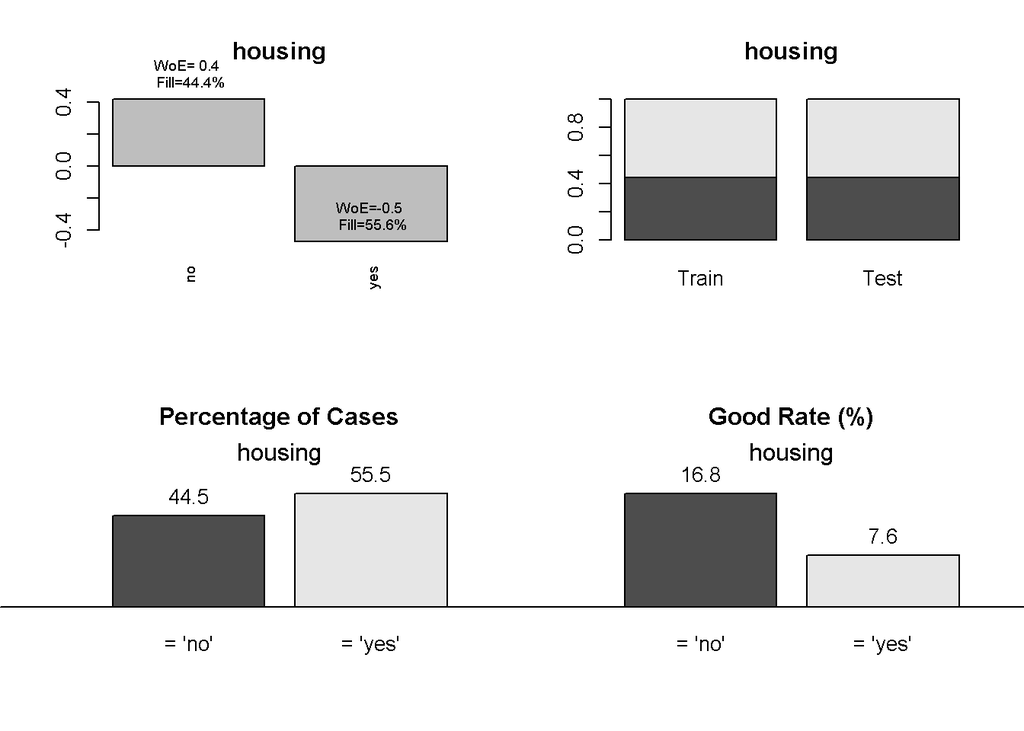

```
## Information Value 0.07
```

```
##      [,1]
## [1,]  0.7
## [2,]  1.9
```

```
## [1] 0.7 1.9
```

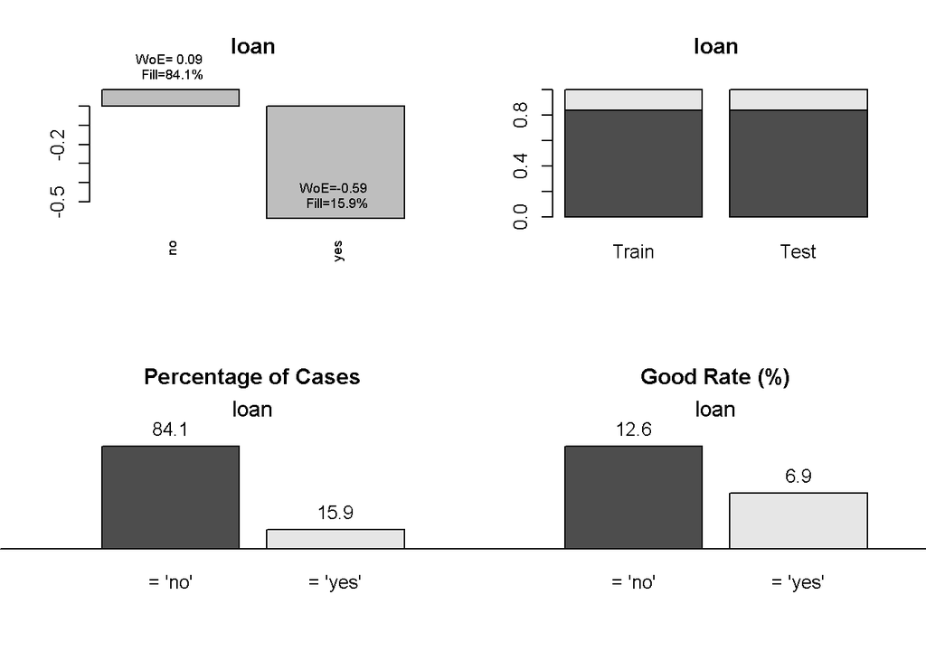

```
## Information Value 0.28
```